# 10-1-kNN_class

2025-02-17

### Code Accompanying *The Machine Learning Handbooks*, Volume I, Chapter 10

#### Book pdf is available on the GitHub repo: https://github.com/kjmazidi/Machine_Learning_3rd_edition

### Introduction

This notebook looks at the built-in data set **iris** as an introductory example of kNN classification in R.

Library imported: class for kNN classification

```r
if (!require(class)){
  install.packages("class")
}
library("class")
```

### Load and look at the data

The iris data set has 150 instances and 5 columns: - Sepal.Length - Sepal.Width - Petal.Length - Petal.Width - Species: setosa, versicolor or virginica

```r
str(iris)    # display the structure of the object
```

```
## 'data.frame':    150 obs. of  5 variables:
##  $ Sepal.Length: num  5.1 4.9 4.7 4.6 5 5.4 4.6 5 4.4 4.9 ...
##  $ Sepal.Width : num  3.5 3 3.2 3.1 3.6 3.9 3.4 3.4 2.9 3.1 ...
##  $ Petal.Length: num  1.4 1.4 1.3 1.5 1.4 1.7 1.4 1.5 1.4 1.5 ...
##  $ Petal.Width : num  0.2 0.2 0.2 0.2 0.2 0.4 0.3 0.2 0.2 0.1 ...
##  $ Species     : Factor w/ 3 levels "setosa","versicolor",..: 1 1 1 1 1 1 1 1 1 1 ...
```

```r
summary(iris)
```

```
##   Sepal.Length    Sepal.Width     Petal.Length    Petal.Width
##  Min.   :4.300   Min.   :2.000   Min.   :1.000   Min.   :0.100
##  1st Qu.:5.100   1st Qu.:2.800   1st Qu.:1.600   1st Qu.:0.300
##  Median :5.800   Median :3.000   Median :4.350   Median :1.300
##  Mean   :5.843   Mean   :3.057   Mean   :3.758   Mean   :1.199
##  3rd Qu.:6.400   3rd Qu.:3.300   3rd Qu.:5.100   3rd Qu.:1.800
##  Max.   :7.900   Max.   :4.400   Max.   :6.900   Max.   :2.500
##        Species
##  setosa    :50
##  versicolor:50
##  virginica :50
##
##
##
```

### Plot the data

We let the 3 classes show as 3 different colors with the bg parameter and the “unclass” values 1, 2, 3 representing the 3 types of irises.

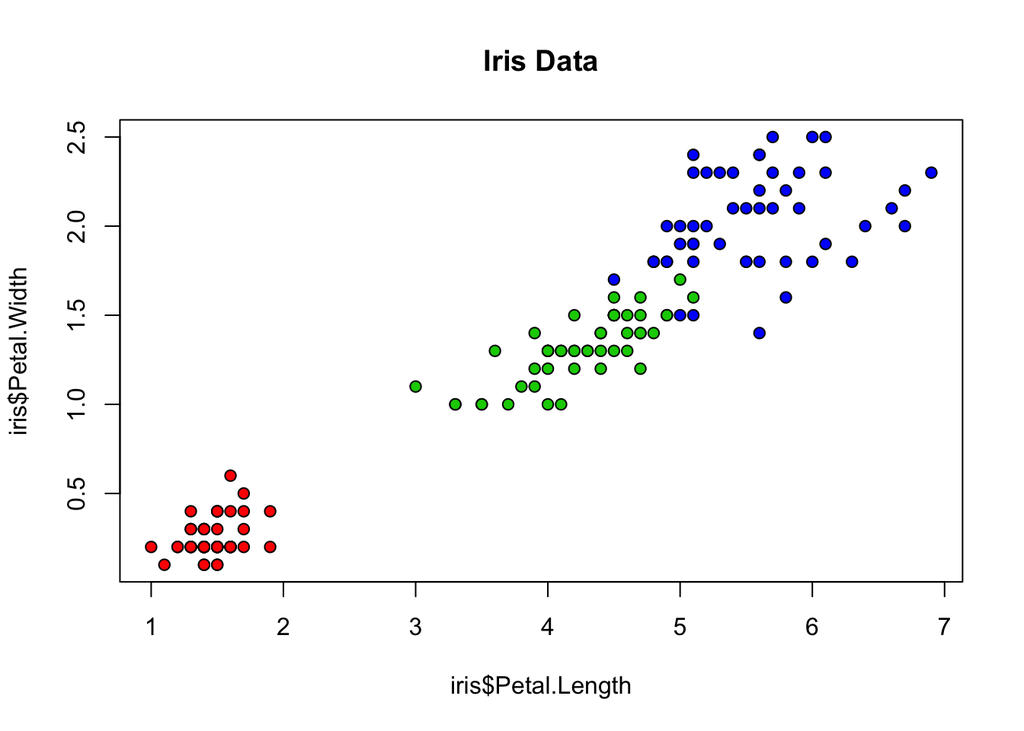

```r
plot(iris$Petal.Length, iris$Petal.Width, pch=21, bg=c("red","green3","blue")
     [unclass(iris$Species)], main="Iris Data")
```

### Pairs scatter plots

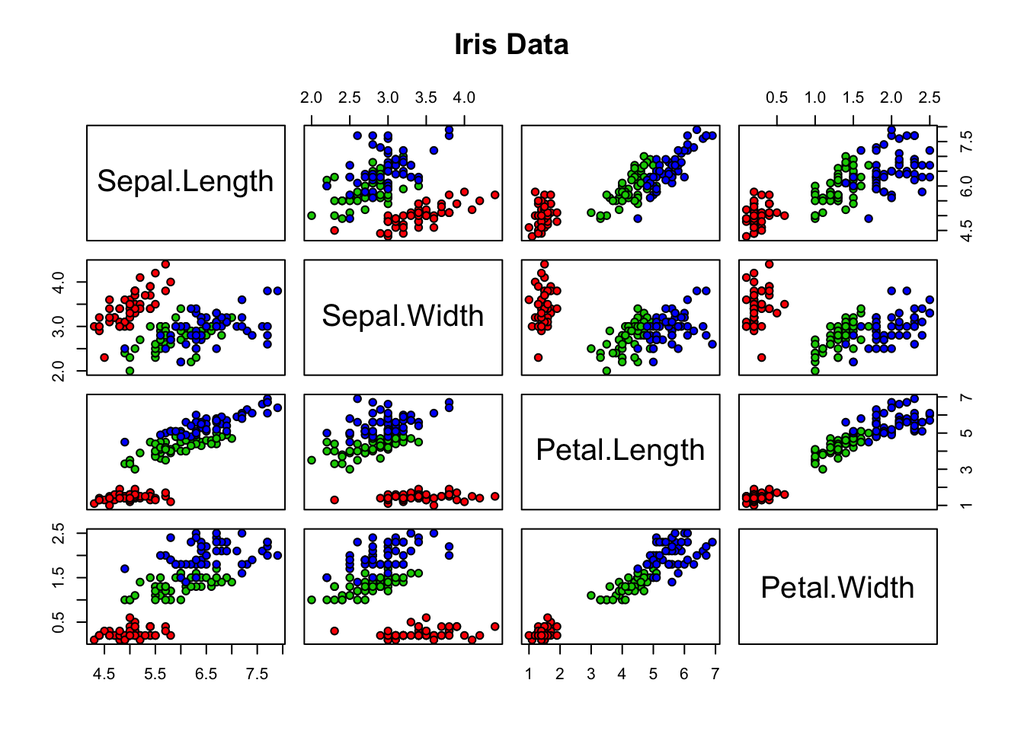

```r
pairs(iris[1:4], main = "Iris Data", pch = 21, bg = c("red", "green3", "blue")[unclass(iris$Species)])
```

### Divide into train/test sets

We will randomly sample the data set to let 2/3 be training and 1/3 test,

```r
set.seed(1958)  # setting a seed gets the same results every time
ind <- sample(2, nrow(iris), replace=TRUE, prob=c(0.67, 0.33))
iris.train <- iris[ind==1, 1:4]
iris.test <- iris[ind==2, 1:4]
iris.trainLabels <- iris[ind==1, 5]
iris.testLabels <- iris[ind==2, 5]
```

### Classify

The knn() function uses Euclidean distance to find the k nearest neighbors.

Classificiation is decided by majority vote with ties broken at random.

Using an odd k can avoid some ties.

```r
iris_pred <- knn(train=iris.train, test=iris.test, cl=iris.trainLabels, k=3)
```

### Compute accuracy

We built a classifier with very high accuracy. Note that the iris data set is quite easy to classify.

```r
results <- iris_pred == iris.testLabels
acc <- length(which(results==TRUE)) / length(results)
# or combine into one line:
#acc <- length(which(iris_pred == iris.testLabels)) / length(iris_pred)
table(results, iris_pred)
```

```
##        iris_pred
## results setosa versicolor virginica
##   FALSE      0          1         0
##   TRUE      17         15        17
```

```r
acc
```

```
## [1] 0.98
```